# Estatística Descritiva & R (II)

```
## [1] "pt_BR/pt_BR/pt_BR/C/pt_BR/C"
```

## Continuação da Aula 03

Na aula 03 estudamos 2 medidas de tendência central e duas medidas de dispersão:

- Medidas de Tendência Central
  - Média
  - Mediana
- Medidas de Dispersão
  - Desvio Padrão
  - Desvio Absoluto da Mediana

Nesta aula continuaremos com mais algumas medidas de tendência central e de dispersão, bem como medidas de associação entre 2 variáveis

- Medidas de Tendência Central
  - Moda
- Medidas de Dispersão
  - Intervalo Interquartil
- Medidas de Associação entre 2 variáveis
  - Covariância
  - Correlação

### Dataset para práticas

Seguiremos com os dados de remuneração de servidores públicos federais no mês de Fevereiro de 2018, pós-processados para uso nesta aula.

```r
library(tidyverse)

subset_salarios <- read_csv("data/201802_dados_salarios_servidores.csv.gz") %>%
  filter(REMUNERACAO_REAIS > 900, !is.na(UF_EXERCICIO)) %>%
  select(ID_SERVIDOR_PORTAL, REMUNERACAO_REAIS, DESCRICAO_CARGO, DATA_INGRESSO_ORGAO, ORGSUP_EXERCICIO, DATA_DIPLOMA_INGRESSO_SERVICOPUBLICO, UF_EXERCICIO)

head(subset_salarios, 20)
```

| ID_SERVIDOR_PORTAL | REMUNERACAO_REAIS | DESCRICAO_CARGO | DATA_INGRESSO_ORGAO | ORGSUP_EXERCICIO | DATA_DIPLOMA_INGRESSO_SERVICOPUBLICO | UF_EXERCICIO |
| --- | --- | --- | --- | --- | --- | --- |
| 1000000 | 10110.93 | TECNICO EM ARTES GRAFICAS | 2008-12-29 | MINISTERIO DA EDUCACAO | 1992-01-22 | RS |
| 1000001 | 9607.00 | ASSISTENTE EM CIENCIA E TECNOLOGIA | 1979-08-20 | MINIST.DA CIENCIA, TECNOLOGIA E INOVACAO | 1979-08-20 | MG |
| 1000004 | 15806.58 | PROFESSOR DO MAGISTERIO SUPERIOR | 2009-03-13 | MINISTERIO DA EDUCACAO | 2009-03-13 | RN |
| 1000005 | 12060.77 | PROFESSOR DO MAGISTERIO SUPERIOR | 2010-01-12 | MINISTERIO DA EDUCACAO | 2004-05-21 | PR |
| 1000010 | 3566.08 | TEC EM SEGURANCA DO TRABALHO | 2014-12-10 | MINISTERIO DA EDUCACAO | 2015-01-28 | RJ |
| 1000015 | 19371.50 | AUDITOR FISCAL FEDERAL AGROPECUARIO | 2007-05-24 | MINIST.DA AGRICULTURA,PECUARIA E ABAST. | 2007-05-24 | RJ |
| 1000016 | 9423.67 | TECNICO | 1988-01-13 | MINIST.DA CIENCIA, TECNOLOGIA E INOVACAO | 1987-04-01 | RJ |
| 1000018 | 13295.05 | ECONOMISTA | 2011-10-27 | MINISTERIO DA EDUCACAO | 1983-04-17 | DF |
| 1000020 | 16952.79 | PROFESSOR ENS BASICO TECN TECNOLOGICO | 2008-12-29 | MINISTERIO DA EDUCACAO | 2006-10-03 | GO |
| 1000021 | 6211.50 | TECNICO DE LABORATORIO AREA | 1995-11-29 | MINISTERIO DA EDUCACAO | 1995-11-29 | PR |

[output cut: 10 more lines]

## Medidas de Tendência Central

Medidas de posição apresentam o valor típico de uma variável

> Uma estimativa do valor esperado para a variável

### Moda

Valor mais frequente em um conjunto. É uma estatística descritiva mais empregada em variáveis categóricas, mas também pode ser utilizada em variáveis numéricas.

Exemplos:

```r
subset_salarios %>%
  count(DESCRICAO_CARGO) %>%
  arrange(desc(n)) %>%
  head(1)
```

| DESCRICAO_CARGO | n |
| --- | --- |
| PROFESSOR DO MAGISTERIO SUPERIOR | 75853 |

```r
ocorrencias_remuneracoes <- table(subset_salarios$REMUNERACAO_REAIS)

(moda_salario <- as.numeric(names(sort(ocorrencias_remuneracoes, decreasing = TRUE))[1]))
```

```
## [1] 9585.67
```

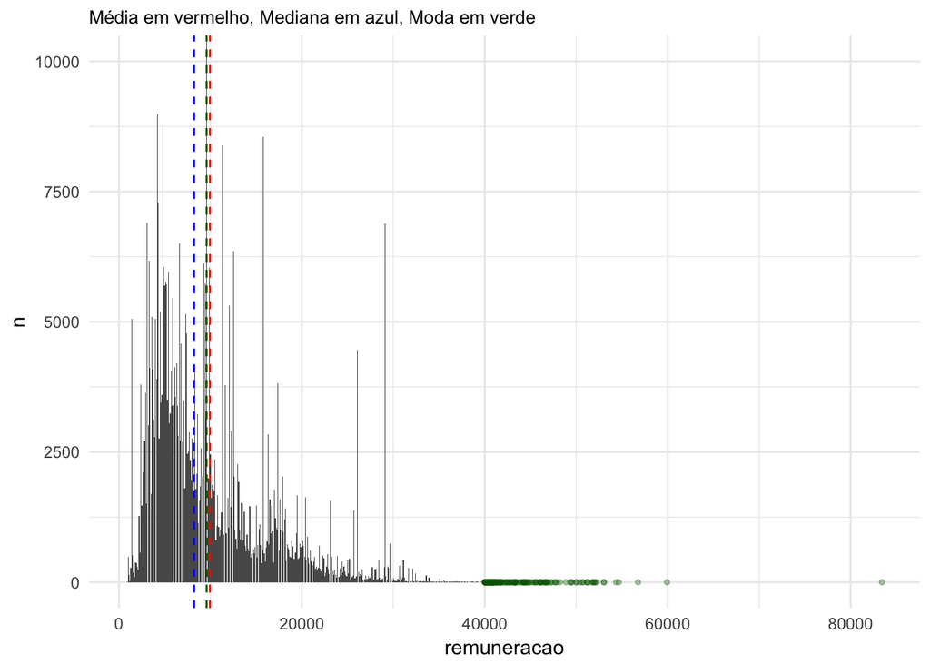

```r
mode <- function(x) {
  as.numeric(names(sort(table(x), decreasing = TRUE))[1])
}

subset_salarios %>%
  mutate(remuneracao = round(REMUNERACAO_REAIS, -2)) %>% # Arredonda para centenas
  count(remuneracao) %>%
  ggplot( aes(x = remuneracao, y = n)) +
  geom_col() +
  geom_vline(xintercept = mean(subset_salarios$REMUNERACAO_REAIS), color="red", size=0.5, linetype="dashed") +
  geom_vline(xintercept = median(subset_salarios$REMUNERACAO_REAIS), color="blue", size=0.5, linetype="dashed") +
  geom_vline(xintercept = mode(subset_salarios$REMUNERACAO_REAIS), color="darkgreen", size=0.5, linetype="dashed") +
  geom_point(data = filter(subset_salarios, REMUNERACAO_REAIS > 40000 ), mapping = aes(x=REMUNERACAO_REAIS), inherit.aes = FALSE, y=0, color="darkgreen", size=1, alpha = 0.3) +
  coord_cartesian(ylim = c(0, 10000)) +
  labs(subtitle = "Média em vermelho, Mediana em azul, Moda em verde") +
  theme_minimal()
```

E quando não há um valor mais frequente?

```r
set.seed(1234)
valores_aleatorios_uniforme <- runif(n = 300, min = 1000, max = 5000)

ocorrencias_valores_aleatorios <- table(valores_aleatorios_uniforme)

# Quantas ocorrências do valor mais frequente?
max(ocorrencias_valores_aleatorios)
```

```
## [1] 1
```

```r
(moda_uniforme <- mode(valores_aleatorios_uniforme))
```

```
## [1] 1013.129
```

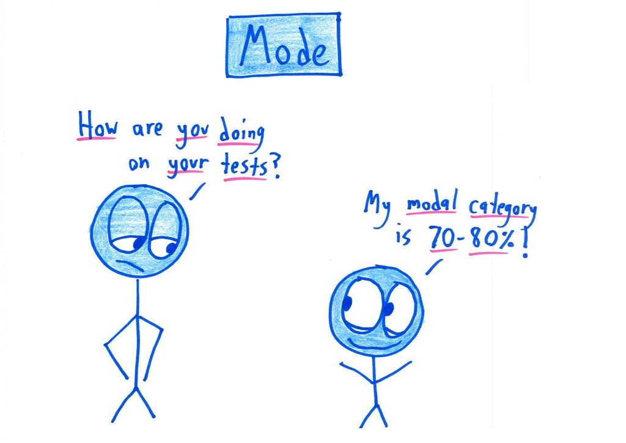

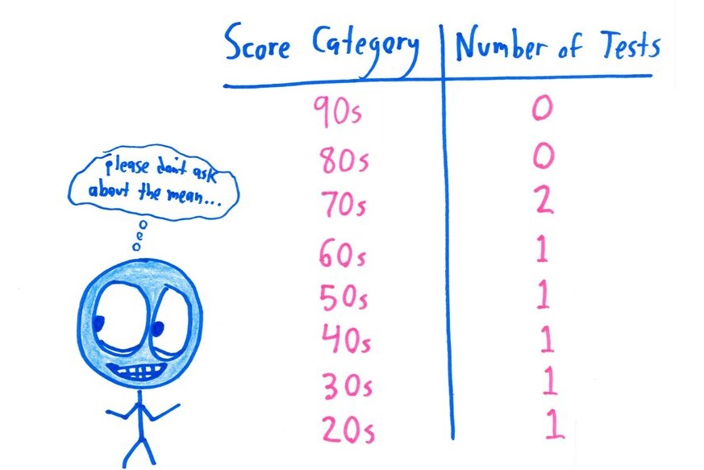

## Medidas de Dispersão

### Intervalo Interquartil

#### Percentis / Quantis

Medida que divide um conjunto ordenado em P% dos valores anteriores à medida e (100-P)% valores acima desta medida.

A mediana é o percentil 50%.

Quartis dividem o conjunto ordenado em 4 valores:

- Quartil 1 (25%)
- Quartil 2, a mediana
- Quartil 3 (75%)

Em R:

```r
## Default S3 method:
quantile(x, probs = seq(0, 1, 0.25), na.rm = FALSE, names = TRUE)
```

Exemplo:

```r
quantile(subset_salarios$REMUNERACAO_REAIS)
```

```
##       0%      25%      50%      75%     100%
##   906.79  4964.57  8214.58 12726.98 83437.51
```

```r
summary(subset_salarios$REMUNERACAO_REAIS)
```

```
##    Min. 1st Qu.  Median    Mean 3rd Qu.    Max.
##   906.8  4964.6  8214.6  9954.8 12727.0 83437.5
```

#### O intervalo interquartil

Diferença entre o Terceiro Quartil e o Primeiro Quartil. Também conhecido pela sigla IQR.

```r
IQR(subset_salarios$REMUNERACAO_REAIS)
```

```
## [1] 7762.41
```

## Medidas de Associação entre 2 variáveis